# Time Series Analysis on Traffic Accident Record in NYC

## Forecasting

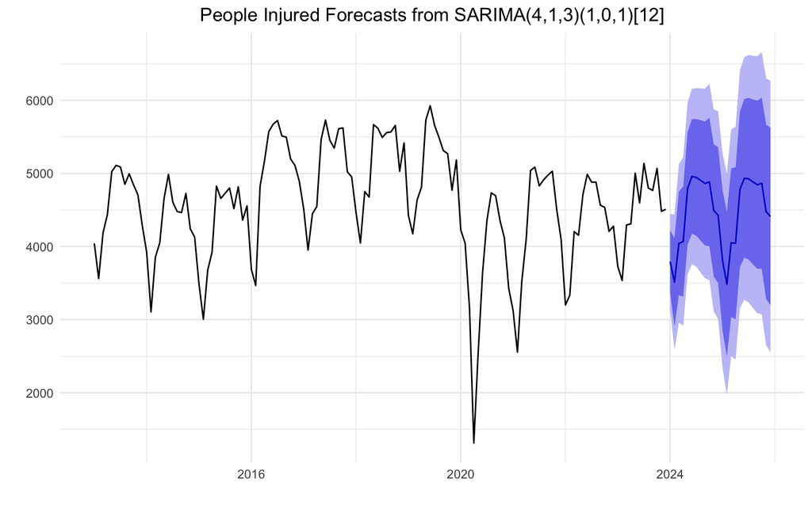

```r
future_forecast <- forecast(sarima_fit, h = 24)

autoplot(future_forecast) +
  labs(title = "People Injured Forecasts from SARIMA(4,1,3)(1,0,1)[12]", x = "", y = "") +
  theme_minimal() +
  theme(plot.title = element_text(hjust = 0.5))
```

Using the fitted SARIMA model on the people injured data, we predict future data for the next 24 months [8]. The dark and light blue colors in the figure represent the ranges of predicted values at 80% and 95% confidence levels, respectively. Despite the broad confidence intervals, a clear annual fluctuation pattern is discernible. This information enables public departments responsible for traffic infrastructure and rules to delve deeper into the causality behind these patterns and devise solutions to reduce traffic-related injuries.

## Conclusion

In conclusion, this study has successfully utilized historical motor vehicle collision data to explore and identify seasonal trends in the number of people injured in New York City. Through careful data exploration, model selection, and diagnostic processes, we have established that the SARIMA(4,1,3)(1,0,1)12 model best fits the seasonal patterns observed in the data. The findings highlight the importance of incorporating seasonal variations into traffic safety planning and intervention strategies. By predicting future trends, public safety departments can allocate resources more effectively and implement targeted measures at times when the risk of injury is highest. Ultimately, this research contributes to the ongoing efforts to enhance road safety and reduce the incidence of traffic-related injuries, highlighting the critical role of data-driven decision-making in public health and safety initiatives.

## Sources

[1] https://www.who.int/news-room/fact-sheets/detail/road-traffic-injuries

[2] https://data.cityofnewyork.us/Public-Safety/Motor-Vehicle-Collisions-Crashes/h9gi-nx95/about_data

[3] https://rpubs.com/davoodastaraky/TSA1

[4] https://www.nyc.gov/site/doh/covid/covid-19-data-totals.page

[5] https://www.sciencedirect.com/science/article/pii/S2352146516300473/pdf?md5=e18c35a7e46868caeb5344403a491bd6&pid=1-s2.0-S2352146516300473-main.pdf

[6] https://ionides.github.io/531w21/midterm_project/project02/project.html

[7] https://ionides.github.io/531w24/05/notes.pdf

[8] https://ionides.github.io/531w22/midterm_project/project17/blinded.html

*R Markdown formatting*

- https://bookdown.org/yihui/rmarkdown/html-document.html#figure-options
- https://github.com/juba/rmdformats?tab=readme-ov-file#robobook

*Proofreading and debugging*

- ChatGPT